# Trends & Disparities in Health Insurance & Utilization among Hispanic Immigrants in the United States, 2011-2018 (BST260 Final Project)

June-Ho Kim

December 2019

*Note: Data is stored in the GitHub repository (https://github.com/junehokim3/hsph-bst260-finalproject). Code is written such that the data is pulled from the repository. Code that does not directly reference the dataset is written so that it is not run when knitting the R Markdown file.*

## Overview and Motivation

The Patient Protection and Affordable Care Act (ACA or colloquially called “Obamacare”) has been associated with decreases in uninsured rates along with improvements in access to care in the United States. Additionally, the ACA may have narrowed certain health disparities by race and ethnicity, though this varies across subgroups and by immigration status. Notably, the provisions of the ACA are not available to undocumented immigrants while non-citizens are eligible for Medicaid after five years of living in the United States (or if they live in a state with special provisions). Therefore, the ACA may have had differential immediate and long-term effects on health insurance coverage and health care utilization based on race/ethnicity and immigration status.

In this study, I am taking a broad overview of recent national health data in order to observe and visualize patterns in insurance and utilization, analyze trends, and identify next steps for further investigation. I focused specifically on comparing the Hispanic immigrant population with the non-immigrant white population as historically there have been large disparities and various policies and rhetoric over the past decade may have had differential effects on the populations.

## Related Work

I am currently collaborating with other Harvard Medical School fellows in health services research to organize a conference on immigrant health. Recent research on immigrant health inspired me to take a look at publicly available national health data in order to wrangle the data myself and better understand trends and patterns for immigrant populations, particularly those that may have been affected both by the ACA and more recent national policies and rhetoric from the Trump administration.

## Initial Questions

My primary question of interest was: following Medicaid expansion, have there been significant and sustained improvements in health insurance coverage and health care utilization among Hispanic non-citizen and naturalized immigrants compared to Non-Hispanic White citizens? This question was comprised of several different other questions:

- What are the demographic characteristics of the three groups?
- What are the overall rates of health care insurance coverage (uninsurance, Medicaid, private insurance, Medicare) and utilization (delays in care, skipping care due to cost, visits to health professionals, difficulty paying bills) by group?
- What are the annual trends in coverage and utilization from 2011 to 2018?
- Assuming 2014 was the primary time of Medicaid expansion, was there a significant change in coverage and utilization for Hispanic immigrants compared to non-Hispanic White citizens?

## Data

My primary data source was the National Health Insurance Survey (NHIS), publicly available data from the Centers for Disease Control (CDC). I used the “Person” datasets from 2011 to 2018 by downloading the corresponding ASCII or CSV files then converting them into .Rdata formats. For example, the 2017 dataset can be found here: ftp://ftp.cdc.gov/pub/Health_Statistics/NCHS/Datasets/NHIS/2017/personsxcsv.zip

```r
### Load libraries ###
library(knitr)
library(nlme) #linear and nonlinear mixed effects models
library(car) #applied regression
library(tidyverse)
library(survey) #complex survey procedures
library(ggplot2)
library(scales)
library(tableone) #descriptive stats for Table 1
library(gridExtra)
library(kableExtra)
```

#### Data Cleaning and Concatenating

Next, I selected my initial variables of interest and cleaned each dataset as necessary in order to allow me to harmoniously concatenate the eight years:

*Note: only 2011 and 2018 shown to save space, filepaths not defined*

```r
### NHIS 2011 Person File ###

load("***/nhis11_person.Rdata") #filepath to raw dataset

nhis11_person <- nhis11_person %>%
  mutate(PSTRAT = STRAT_P+1000) %>% #rename and also renumber since strata are different from later years
  rename(PPSU = PSU_P) #rename to match other years

nhis11_immig <- subset(nhis11_person, select = c(SRVY_YR, HHX, INTV_MON, FMX, FPX, WTIA, WTFA, REGION, PSTRAT, PPSU, SEX, ORIGIN_I, HISPAN_I, RACERPI2, MRACRPI2, MRACBPI2, RACRECI3, HISCODI3, AGE_P, R_MARITL, CDCMSTAT, LATIME7, LAUNIT7, LADURA7, LADURB7, LACHRC7, LATIME9, LAUNIT9, LADURA9, LADURB9, LACHRC9, LATIME10, LAUNIT10, LADURA10, LADURB10, LACHRC10, LATIME11, LAUNIT11, LADURA11, LADURB11, LACHRC11, LATIME12, LAUNIT12, LADURA12, LADURB12, LACHRC12, LATIME17, LAUNIT17, LADURA17, LADURB17, LACHRC17, LATIME29, LAUNIT29, LADURA29, LADURB29, LACHRC29, PHSTAT, PDMED12M, PNMED12M, PHOSPYR2, HOSPNO, HPNITE, PHCDV2W, PHCDVN2W, P10DVYR, NOTCOV, MEDICARE, MCPART, MCCHOICE, MEDICAID, HICOSTR1, HICOSTR2, HILAST, HISTOP1, HISTOP2, HISTOP3, HISTOP4, HISTOP5, HISTOP6, HISTOP7, HISTOP8, HISTOP9, HISTOP10, HISTOP11, HISTOP12, HISTOP13, HISTOP14, HISTOP15, HINOTYR, HINOTMYR, FHICHNG, FHIKDBA, FHIKDBB, FHIKDBC, FHIKDBD, FHIKDBE, FHIKDBF, FHIKDBG, FHIKDBH, FHIKDBI, FHIKDBJ, FHIKDBK, HCSPFYR, MEDBILL, MEDBPAY, MEDBNOP, FSA, HIKINDNA, HIKINDNB, HIKINDND, HIKINDNE, HIKINDNF, HIKINDNG, HIKINDNH, HIKINDNI, HIKINDNJ, HIKINDNK, MCAREPRB, MCAIDPRB, SINCOV, PLBORN, REGIONBR, GEOBRTH, YRSINUS, CITIZENP, EDUC1, DOINGLWP, WHYNOWKP, WRKHRS2, WRKFTALL, WRKLYR1, WRKMYR, ERNYR_P, HIEMPOF))

save(nhis11_immig, file = "***/nhis11_immig.Rdata")

### NHIS 2018 Person File ###

load("***/nhis18_person.Rdata")

nhis18_person <- nhis18_person %>%
  rename(HILAST = HILAST2, HOSPNO = HOSPNO_P, HPNITE = HPNITE_P, PHCDVN2W = PHCDN2WP)

nhis18_immig <- subset(nhis18_person, select = c(SRVY_YR, HHX, INTV_MON, FMX, FPX, WTIA, WTFA, REGION, PSTRAT, PPSU, SEX, ORIGIN_I, HISPAN_I, RACERPI2, MRACRPI2, MRACBPI2, RACRECI3, HISCODI3, AGE_P, R_MARITL, CDCMSTAT, LATIME7, LAUNIT7, LADURA7, LADURB7, LACHRC7, LATIME9, LAUNIT9, LADURA9, LADURB9, LACHRC9, LATIME10, LAUNIT10, LADURA10, LADURB10, LACHRC10, LATIME11, LAUNIT11, LADURA11, LADURB11, LACHRC11, LATIME12, LAUNIT12, LADURA12, LADURB12, LACHRC12, LATIME17, LAUNIT17, LADURA17, LADURB17, LACHRC17, LATIME29, LAUNIT29, LADURA29, LADURB29, LACHRC29, PHSTAT, PDMED12M, PNMED12M, PHOSPYR2, HOSPNO, HPNITE, PHCDV2W, PHCDVN2W, P10DVYR, NOTCOV, MEDICARE, MCPART, MCCHOICE, MEDICAID, HICOSTR1, HICOSTR2, HILAST, HISTOP1, HISTOP2, HISTOP3, HISTOP4, HISTOP5, HISTOP6, HISTOP7, HISTOP8, HISTOP9, HISTOP10, HISTOP11, HISTOP12, HISTOP13, HISTOP14, HISTOP15, HINOTYR, HINOTMYR, FHICHNG, FHIKDBA, FHIKDBB, FHIKDBC, FHIKDBD, FHIKDBE, FHIKDBF, FHIKDBG, FHIKDBH, FHIKDBI, FHIKDBJ, FHIKDBK, HCSPFYR, MEDBILL, MEDBPAY, MEDBNOP, FSA, HIKINDNA, HIKINDNB, HIKINDND, HIKINDNE, HIKINDNF, HIKINDNG, HIKINDNH, HIKINDNI, HIKINDNJ, HIKINDNK, MCAREPRB, MCAIDPRB, SINCOV, PLBORN, REGIONBR, GEOBRTH, YRSINUS, CITIZENP, EDUC1, DOINGLWP, WHYNOWKP, WRKHRS2, WRKFTALL, WRKLYR1, WRKMYR, ERNYR_P, HIEMPOF))

save(nhis18_immig, file = "***/nhis18_immig.Rdata")

##### Combine datasets #####
nhis_immig <- rbind(nhis11_immig, nhis12_immig)
nhis_immig <- rbind(nhis_immig, nhis13_immig)
nhis_immig <- rbind(nhis_immig, nhis14_immig)
nhis_immig <- rbind(nhis_immig, nhis15_immig)
nhis_immig <- rbind(nhis_immig, nhis16_immig)
nhis_immig <- rbind (nhis_immig, nhis17_immig)
nhis_immig <- rbind(nhis_immig, nhis18_immig)

save(nhis_immig, file = "***/nhis_immig.Rdata")
```

#### Data Wrangling for Analysis

After creating a master file, I renamed variables, recoded answer choices, selected variables of interest, and created new variables:

```
## SHA-1 hash of the downloaded data file is:
## fd11a757ba7eb8c92c7204c536fffc08de85c719
```

```
## [1] "nhis_immig"
```

```r
################################################################################
# Data Wrangling Part 1- Renaming and Recoding Variables
################################################################################
nhis_immig$year <- nhis_immig$SRVY_YR
nhis_immig$hhnum <- nhis_immig$HHX

nhis_immig$month <- nhis_immig$INTV_MON #1=Jan, 2=Feb, 3=Mar, etc

nhis_immig$famnum <- nhis_immig$FMX
nhis_immig$personnum <- nhis_immig$FPX
nhis_immig$wtinterim <- (nhis_immig$WTIA)/8
nhis_immig$wtfinal <- (nhis_immig$WTFA)/8

nhis_immig$region <- nhis_immig$REGION #1=Northeast, 2=Midwest, 3=South, 4=West
nhis_immig$region <- as.factor(nhis_immig$region)

nhis_immig$strata <- nhis_immig$PSTRAT
nhis_immig$psu <- nhis_immig$PPSU

nhis_immig$sex <- nhis_immig$SEX #1=male, 2=female
nhis_immig$sex <- as.factor(nhis_immig$sex)

nhis_immig$hispanic <- nhis_immig$ORIGIN_I #1=yes, 2=no
nhis_immig$hispanic <- as.factor(nhis_immig$hispanic)

nhis_immig$raceethn <- nhis_immig$HISCODI3 #1=hispanic, 2=non-hispanic white,
  # 3=non-hispanic black, 4=non-hispanic asian, 5=non-hispanic other
nhis_immig$raceethn <- as.factor(nhis_immig$raceethn)

nhis_immig$age <- nhis_immig$AGE_P #0=under 1 yr, 1-84=1-84 yrs, 85=85+ yrs

nhis_immig$marital <- nhis_immig$CDCMSTAT #1=separated, 2=divorced, 3=married, 4=single/never married
  # 5=widowed #9=unknown marital status
nhis_immig$marital <- as.factor(nhis_immig$marital)

nhis_immig$hearttime <- nhis_immig$LATIME7
nhis_immig$heartunit <- nhis_immig$LAUNIT7
nhis_immig$heartyrs <- nhis_immig$LADURA7
nhis_immig$heartmos <- nhis_immig$LADURB7
nhis_immig$heartchronic <- nhis_immig$LACHRC7 #1=chronic, 2=not chronic

nhis_immig$stroketime <- nhis_immig$LATIME8
nhis_immig$strokeunit <- nhis_immig$LAUNIT8
nhis_immig$strokeyrs <- nhis_immig$LADURA8
nhis_immig$strokemos <- nhis_immig$LADURB8
nhis_immig$strokechronic <- nhis_immig$LACHRC8 #1=chronic, 2=not chronic

nhis_immig$htntime <- nhis_immig$LATIME9
nhis_immig$htnunit <- nhis_immig$LAUNIT9
nhis_immig$htnyrs <- nhis_immig$LADURA9
nhis_immig$htnmos <- nhis_immig$LADURB9
nhis_immig$htnchronic <- nhis_immig$LACHRC9 #1=chronic, 2=not chronic

nhis_immig$dmtime <- nhis_immig$LATIME10
nhis_immig$dmunit <- nhis_immig$LAUNIT10
nhis_immig$dmyrs <- nhis_immig$LADURA10
nhis_immig$dmmos <- nhis_immig$LADURB10
nhis_immig$dmchronic <- nhis_immig$LACHRC10 #1=chronic, 2=not chronic

nhis_immig$lungtime <- nhis_immig$LATIME11
nhis_immig$lungunit <- nhis_immig$LAUNIT11
nhis_immig$lungyrs <- nhis_immig$LADURA11
nhis_immig$lungmos <- nhis_immig$LADURB11
nhis_immig$lungchronic <- nhis_immig$LACHRC11 #1=chronic, 2=not chronic

nhis_immig$cancertime <- nhis_immig$LATIME12
nhis_immig$cancerunit <- nhis_immig$LAUNIT12
nhis_immig$canceryrs <- nhis_immig$LADURA12
nhis_immig$cancermos <- nhis_immig$LADURB12
nhis_immig$cancerchronic <- nhis_immig$LACHRC12 #1=chronic, 2=not chronic

nhis_immig$depresstime <- nhis_immig$LATIME17
nhis_immig$depressnit <- nhis_immig$LAUNIT17
nhis_immig$depressyrs <- nhis_immig$LADURA17
nhis_immig$depressmos <- nhis_immig$LADURB17
nhis_immig$depresschronic <- nhis_immig$LACHRC17 #1=chronic, 2=not chronic

nhis_immig$substtime <- nhis_immig$LATIME29
nhis_immig$substunit <- nhis_immig$LAUNIT29
nhis_immig$substyrs <- nhis_immig$LADURA29
nhis_immig$substmos <- nhis_immig$LADURB29
nhis_immig$substchronic <- nhis_immig$LACHRC29 #1=chronic, 2=not chronic

nhis_immig$prom <- nhis_immig$PHSTAT
nhis_immig$prom <- ifelse(nhis_immig$prom==1 | nhis_immig$prom==2, 1, 0)

nhis_immig$delaycare <- nhis_immig$PDMED12M #Has medical care been delayed for __ due to cost in past 12 months
nhis_immig$delaycare <- ifelse(nhis_immig$delaycare==1, 1, 0)

nhis_immig$misscare <- nhis_immig$PNMED12M #Needed but did NOT get medical care due to cost in past 12 months
nhis_immig$misscare <- ifelse(nhis_immig$misscare==1, 1, 0)

nhis_immig$hospnite <- nhis_immig$PHOSPYR2 #Hospital overnight in past 12 mos
nhis_immig$hosptimenum <- nhis_immig$HOSPNO #No. of times in hospital o/n, 12 mos
nhis_immig$hospnitenum <- nhis_immig$HPNITE #No. of nights in hospital, 12 mos

nhis_immig$clinicvisit <- nhis_immig$PHCDV2W #Did __ see health professional in office, 2 wks
nhis_immig$clinicvisit <- ifelse(nhis_immig$clinicvisit==1, 1, 0)

nhis_immig$clinicvisitnum <- nhis_immig$PHCDVN2W #No. of times visited health professional, 2 wks

nhis_immig$clinicvisitfreq10 <- nhis_immig$P10DVYR #Did __ receive care 10+ times in 12 mos
nhis_immig$clinicvisitfreq10 <- ifelse(nhis_immig$clinicvisitfreq10==1, 1, 0)

nhis_immig$covered <- nhis_immig$NOTCOV #1=not covered, 2=covered, 9=don't know
nhis_immig$covered <- as.factor(nhis_immig$covered)

nhis_immig$medicare <- nhis_immig$MEDICARE #1 & 2=yes, 3=no, 4=refused, 9=don't know
nhis_immig$medicare <- as.factor(nhis_immig$medicare)

nhis_immig$medicarepart <- nhis_immig$MCPART #1-Part A, 2-Part B, 3-A&B, 7-refused, 8-not ascertained, 9-don't know
nhis_immig$medicarepart <- as.factor(nhis_immig$medicarepart)

nhis_immig$medadvantage <- nhis_immig$MCCHOICE #1-yes 2-no 7-refused 8-not ascertained 9-don't know
nhis_immig$medadvantage <- as.factor(nhis_immig$medadvantage)

nhis_immig$medicaid <- nhis_immig$MEDICAID #1 & 2=yes, 3=no, 4=refused, 9=don't know
nhis_immig$medicaid <- as.factor(nhis_immig$medicaid)

nhis_immig$nocover <- nhis_immig$HINOTYR #No health coverage during past 12 mos, 1-yes, 2-no
nhis_immig$nocover <- as.factor(nhis_immig$nocover)

nhis_immig$nocovermos <- nhis_immig$HINOTMYR #Mos w/o coverage in past 12 mos
nhis_immig$healthcost <- nhis_immig$HCSPFYR #Amt family spent for medical care, 0-zero, 1-<500, 2-500-1999,
  # 3-2000-2999, 4-3000-4999, 5-5000+, 7-refused, 8-not ascertained, 9-don't know
nhis_immig$healthcost <- as.factor(nhis_immig$healthcost)

nhis_immig$billprob <- nhis_immig$MEDBILL #Problems paying medical bills, 1-yes, 2-no, 7-refused, 8-not ascert, 9-don't know
nhis_immig$billprob <- ifelse(nhis_immig$billprob==1, 1, 0)

nhis_immig$billpaytime <- nhis_immig$MEDBPAY #Bills being paid off over time, 1-yes, 2-no, 7-refused, 8-not ascert, 9-don't know
nhis_immig$billpaytime <- ifelse(nhis_immig$billpaytime==1, 1, 0)

nhis_immig$billnopay <- nhis_immig$MEDBNOP #Unable to pay medical bills, 1-yes, 2-no, 7-refused, 8-not ascert, 9-don't know
nhis_immig$billnopay <- ifelse(nhis_immig$billnopay==1, 1, 0)

nhis_immig$private <- nhis_immig$HIKINDNA #Private health insurance, 1-mentioned, 2-not mentioned, 7-refused, 8-not ascert, 9-don't know
nhis_immig$private <- ifelse(nhis_immig$private==1, 1, 0)

nhis_immig$mcare <- nhis_immig$HIKINDNB #Medicare, 1-yes, 2-no, 7-refused, 8-not ascert, 9-don't know
nhis_immig$mcare <- ifelse(nhis_immig$mcare==1, 1, 0)

nhis_immig$mcaid <- nhis_immig$HIKINDND #Medicaid, 1-yes, 2-no, 7-refused, 8-not ascert, 9-don't know
nhis_immig$mcaid <- ifelse(nhis_immig$mcaid==1, 1, 0)

nhis_immig$schip <- nhis_immig$HIKINDNE #SCHIP, 1-yes, 2-no, 7-refused, 8-not ascert, 9-don't know
nhis_immig$schip <- ifelse(nhis_immig$schip==1, 1, 0)

nhis_immig$militarycare <- nhis_immig$HIKINDNF #Military health care, 1-yes, 2-no, 7-refused, 8-not ascert, 9-don't know
nhis_immig$private <- ifelse(nhis_immig$private==1, 1, 0)

nhis_immig$ihs <- nhis_immig$HIKINDNG #Indian health service, 1-yes, 2-no, 7-refused, 8-not ascert, 9-don't know
nhis_immig$ihs <- ifelse(nhis_immig$ihs==1, 1, 0)

nhis_immig$stateplan <- nhis_immig$HIKINDNH #State-sponsored health plan, 1-yes, 2-no, 7-refused, 8-not ascert, 9-don't know
nhis_immig$stateplan <- ifelse(nhis_immig$stateplan==1, 1, 0)

nhis_immig$othgovtplan <- nhis_immig$HIKINDNI #Other govt plan, 1-yes, 2-no, 7-refused, 8-not ascert, 9-don't know
nhis_immig$othgovtplan <- ifelse(nhis_immig$othgovtplan==1, 1, 0)

nhis_immig$singleservice <- nhis_immig$HIKINDNJ #Single service plan, 1-yes, 2-no, 7-refused, 8-not ascert, 9-don't know
nhis_immig$singleservice <- ifelse(nhis_immig$singleservice==1, 1, 0)

nhis_immig$nocoverage <- nhis_immig$HIKINDNK #NO coverage of any type, 1-yes, 2-no, 7-refused, 8-not ascert, 9-don't know
nhis_immig$nocoverage <- ifelse(nhis_immig$nocoverage==1, 1, 0)

nhis_immig$usborn <- nhis_immig$PLBORN #Born in U.S., 1-yes, 2-no, 7-refused, 8-not ascert, 9-don't know
nhis_immig$usborn <- as.factor(nhis_immig$usborn)

nhis_immig$regionborn <- nhis_immig$REGIONBR #Geographic region of birth recode,
  #1-US, 2-Mexico, Central Am, Caribeean, 3-S America, 4-Europe, 5-Russia, 6-Africa, 7-Middle East...
nhis_immig$regionborn <- as.factor(nhis_immig$regionborn)

nhis_immig$yrsus <- nhis_immig$YRSINUS #Years in U.S., 1-<1yr, 2-1-5yrs, 3-5-10yrs, 4-10-15yrs, 5-15+yrs, 9-unknown
nhis_immig$yrsus <- ifelse(nhis_immig$yrsus==1 | nhis_immig$yrsus==2, 1, 0)
#Recode for <5 yrs vs >5 yrs in U.S.

nhis_immig$citizen <- nhis_immig$CITIZENP #US citizenship status, 1-yes, 2-no, 7-refused, 8-not ascert, 9-don't know
nhis_immig$citizen <- as.factor(nhis_immig$citizen)

nhis_immig$educ <- nhis_immig$EDUC1 #Highest level of school completed
nhis_immig$educ <- as.factor(nhis_immig$educ)

nhis_immig$earnings <- nhis_immig$ERNYR_P #Total earnings last year
nhis_immig$earnings <- as.factor(nhis_immig$earnings)

################################################################################
# Data Wrangling Part 2 - Subset Variables & Create New Variables
################################################################################
nhisAnalysis <- nhis_immig %>%
  select(year, month, wtfinal, region, strata, psu, sex, hispanic,
         raceethn, age, marital, prom, delaycare, misscare, hospnite,
         hosptimenum, hospnitenum, clinicvisit, clinicvisitnum, clinicvisitfreq10,
         healthcost, billprob, billpaytime, billnopay, private, mcare, mcaid, schip,
         nocoverage, usborn, regionborn, yrsus, citizen, educ, earnings)

# Define immigrant vs not - Hispanic immigrant non-citizen (raceethn = 1 + usborn = 2 + regionborn = 2 OR 3 +
  # citizen = 2) vs Hispanic immigrant citizen (raceethn = 1 + usborn = 2 + regionborn = 2 OR 3 +
  # citizen = 1) vs white non-immigrant (raceethn = 2 + usborn = 1)
nhisAnalysis <- nhisAnalysis %>%
  mutate (
    immig = ifelse(raceethn==1 & usborn==2 & (regionborn==2 | regionborn==3) & citizen==2, 1, ifelse(raceethn==1 & usborn==2 & (regionborn==2 | regionborn==3) & citizen==1, 2, ifelse(raceethn==2 & usborn==1,3,NA)))
    )

# Define time (in years)
nhisAnalysis <- nhisAnalysis %>%
  mutate (
    time = year-2010
  )

# Define denominator (annual population by group)
nhisAnalysis <- nhisAnalysis %>%
  group_by(immig) %>% add_count(time, name="pop_year")

# Create new dataset with annual outcomes by group
nhisOutcomes <- nhisAnalysis %>%
  group_by(immig, time) %>%
  summarize(uninsuredrate = sum(nocoverage)*100 / mean(pop_year),
    medicaidrate = sum(mcaid)*100 / mean(pop_year),
    delayrate = sum(delaycare)*100 / mean(pop_year),
    healthrate = sum(prom)*100 / mean(pop_year),
    missrate = sum(misscare)*100 / mean(pop_year),
    billprobrate = sum(billprob)*100 / mean(pop_year),
    billpayrate = sum(billpaytime)*100 / mean(pop_year),
    clinicrate = sum(clinicvisit)*100 / mean(pop_year),
    clinic10rate = sum(clinicvisitfreq10)*100 / mean(pop_year)
  )
```

## Exploratory Analysis

For my exploratory analysis, I first created a “Table 1” in order to look at various characteristics across the three groups of interest (Hispanic immigrant non-citizen, Hispanic immigrant citizen, and Non-Hispanic White citizen). For this analysis, I did not incorporate survey weights.

| Variable | Level | Hispanic.immigrant.non.citizen | Hispanic.immigrant.naturalized.citizen | Non.Hispanic.White.citizen | P.value |
| --- | --- | --- | --- | --- | --- |
| Total (unweighted) |  | 38713 | 25339 | 431559 |  |
| Survey year, no. (%) | 2011 | 6385 (16.5) | 3609 (14.2) | 51429 (11.9) | <0.001 |
|  | 2012 | 6345 (16.4) | 3648 (14.4) | 56370 (13.1) |  |
|  | 2013 | 6046 (15.6) | 3736 (14.7) | 54486 (12.6) |  |
|  | 2014 | 6219 (16.1) | 3739 (14.8) | 60401 (14.0) |  |
|  | 2015 | 5525 (14.3) | 3726 (14.7) | 55588 (12.9) |  |
|  | 2016 | 3190 (8.2) | 2542 (10.0) | 60895 (14.1) |  |
|  | 2017 | 2572 (6.6) | 2126 (8.4) | 48394 (11.2) |  |
|  | 2018 | 2431 (6.3) | 2213 (8.7) | 43996 (10.2) |  |
| U.S. region, no. (%) | Northeast | 4234 (10.9) | 5282 (20.8) | 77326 (17.9) | <0.001 |
|  | Midwest | 3502 (9.0) | 1865 (7.4) | 117319 (27.2) |  |
|  | South | 14576 (37.7) | 9443 (37.3) | 140151 (32.5) |  |
|  | West | 16401 (42.4) | 8749 (34.5) | 96763 (22.4) |  |
| Sex, no. (%) | Male | 19454 (50.3) | 11374 (44.9) | 211275 (49.0) | <0.001 |
|  | Female | 19259 (49.7) | 13965 (55.1) | 220284 (51.0) |  |
| Age, mean (SD) |  | 38.00 (14.72) | 48.93 (17.23) | 41.10 (23.40) | <0.001 |
| Marital status, no. (%) | Separated | 1867 (5.0) | 1089 (4.4) | 4971 (1.4) | <0.001 |
|  | Divorced | 1859 (5.0) | 2772 (11.2) | 40930 (11.3) |  |
|  | Married | 21621 (58.1) | 14982 (60.5) | 197838 (54.8) |  |
|  | Single/never married | 10888 (29.3) | 4305 (17.4) | 92768 (25.7) |  |
|  | Widowed | 840 (2.3) | 1550 (6.3) | 23434 (6.5) |  |
|  | Unknown | 113 (0.3) | 75 (0.3) | 929 (0.3) |  |
| Self-reported health, no. (%) | Not excellent or very good health | 18089 (46.7) | 12431 (49.1) | 139575 (32.3) | <0.001 |
|  | Excellent or very good health | 20624 (53.3) | 12908 (50.9) | 291984 (67.7) |  |
| Delayed care in past yr, no. (%) | No | 34245 (88.5) | 23237 (91.7) | 399243 (92.5) | <0.001 |
|  | Yes | 4468 (11.5) | 2102 (8.3) | 32316 (7.5) |  |
| Missed necessary care due to cost in past yr, no. (%) | No | 34980 (90.4) | 23691 (93.5) | 409845 (95.0) | <0.001 |
|  | Yes | 3733 (9.6) | 1648 (6.5) | 21714 (5.0) |  |
| Hospitalized in past yr, no. (%) | Yes | 2048 (5.3) | 1931 (7.6) | 36168 (8.4) | <0.001 |
|  | No | 36649 (94.7) | 23388 (92.3) | 394836 (91.5) |  |

[output cut: 78 more lines]

I also ran some quick plots to visualize some baseline demographics, such as age:

##### AGE

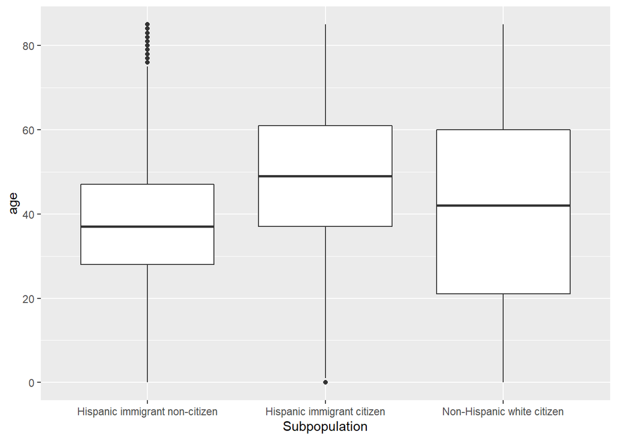

```r
nhisAnalysis %>% filter(!is.na(immig)) %>%
  ggplot(aes(x = as.factor(immig), y = age)) +
  geom_boxplot() +
  scale_x_discrete(labels=c("Hispanic immigrant non-citizen","Hispanic immigrant citizen","Non-Hispanic white citizen")) +
  xlab("Subpopulation")
```

Then, as my main visualizations, I used line plots to map trends in health insurance coverage and utilization from 2011 to 2018.

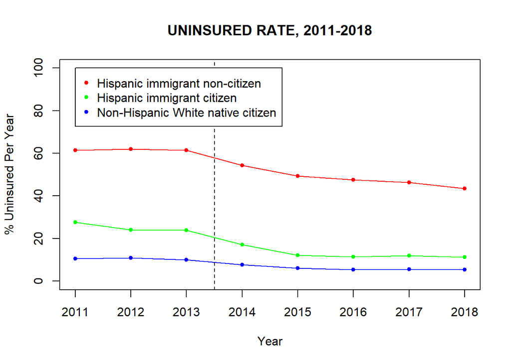

```r
##### PRIMARY OUTCOME: UNINSURED RATE #####
# Plot time series for Hispanic immigrant non-citizens
plot(nhisOutcomes$time[1:8],nhisOutcomes$uninsuredrate[1:8],
     ylab="% Uninsured Per Year",
     ylim=c(0,100),
     main="UNINSURED RATE, 2011-2018",
     xlab="Year",
     type="l",
     col="red",
     xaxt="n")

# Plot Hispanic immigrant naturalized citizens
points(nhisOutcomes$time[9:16],nhisOutcomes$uninsuredrate[9:16],
       type='l',
       col="green")

# Plot non-immigrant White people
points(nhisOutcomes$time[17:24],nhisOutcomes$uninsuredrate[17:24],
       type='l',
       col="blue")

# X-axis year labels
axis(1, at=1:8, labels=2011:2018)

# Add in points
points(nhisOutcomes$time[1:8],nhisOutcomes$uninsuredrate[1:8],
       col="red",
       pch=20)

points(nhisOutcomes$time[9:16],nhisOutcomes$uninsuredrate[9:16],
       col="green",
       pch=20)

points(nhisOutcomes$time[17:24],nhisOutcomes$uninsuredrate[17:24],
       col="blue",
       pch=20)

# Label timepoint for Medicaid Expansion
abline(v=3.5,lty=2)

# Add in a legend
legend(x=1, y=100, legend=c("Hispanic immigrant non-citizen","Hispanic immigrant citizen","Non-Hispanic White native citizen"),
       col=c("red","green","blue"),pch=20)
```

In the primary visualization, it is evident that there are large and persistent health insurance coverage disparities between Hispanic immigrant non-citizens and non-Hispanic White citizens. In 2011, ~60% of the Hispanic immigrant non-citizen population is uninsured. The disparities narrow for Hispanic naturalized citizens after 2013 but still exist in 2018. In this unadjusted visualization, it appears an event in 2014 was associated with a notable decrease in the uninsured population, particularly amongst Hispanic immigrants.

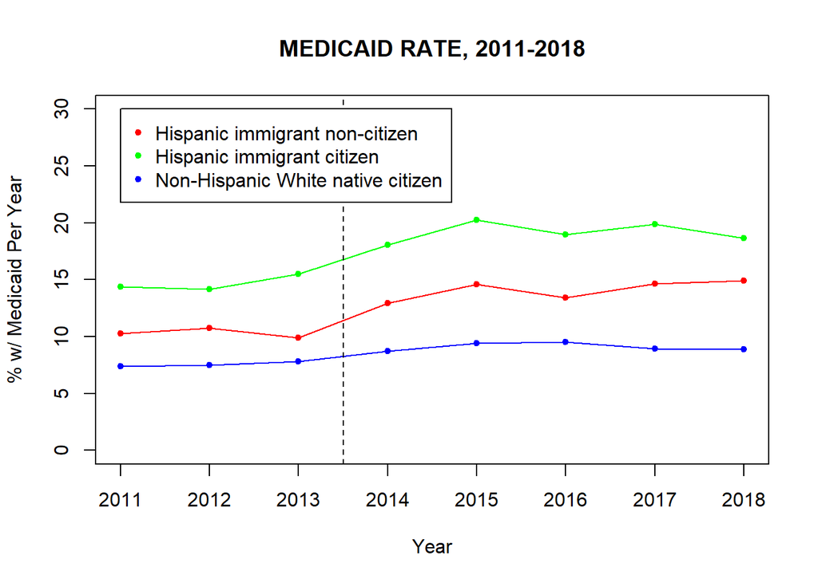

In this secondary visualization, there appears to be a significant rise in the proportion of the each population with Medicaid, especially from 2014. This increase is most noticeable in the Hispanic immigrant population.

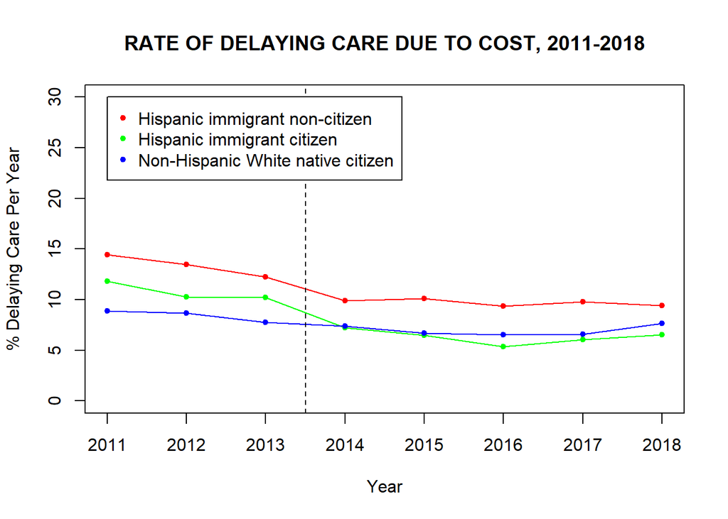

In this figure, there is an overall decrease in the proportion of people who delayed health care due to cost. For the Hispanic immigrant non-citizen population, this decrease appears to occur from 2011 onwards with a steeper decline in 2014 then a plateau from then on. For Hispanic immigrant citizens, there is a large decrease that occurs in 2014 and brings rates in line with the non-Hispanic white native citizen population.

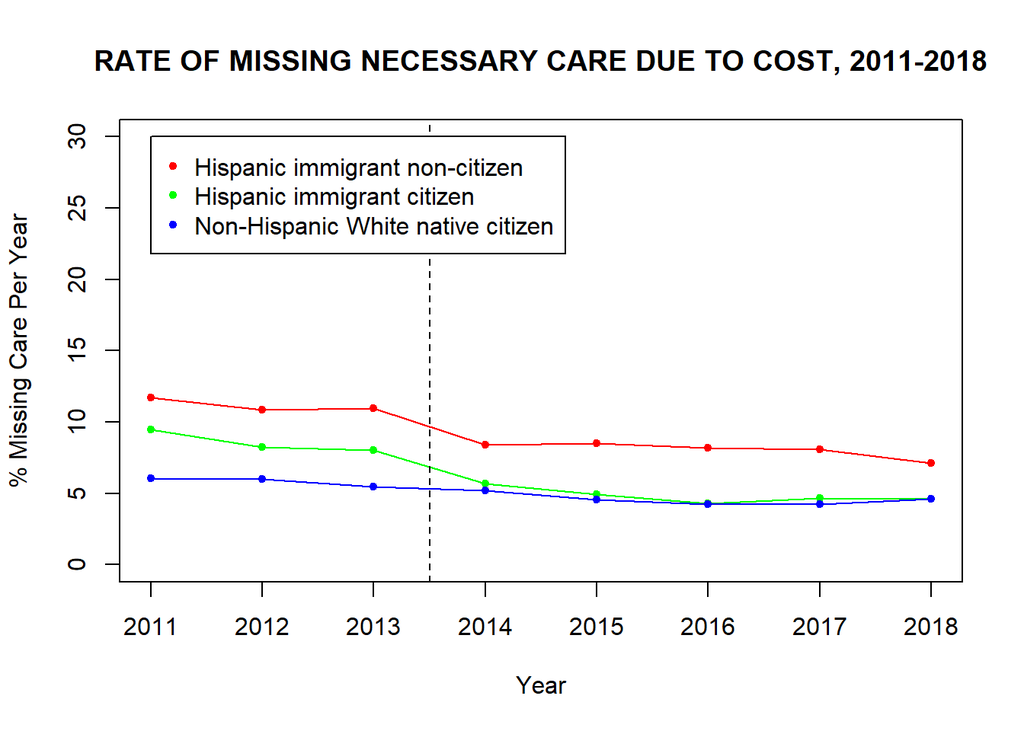

Overall, there is a similar trend in the rate of people delaying care due to cost and the rate of people missing necessary care due to cost.

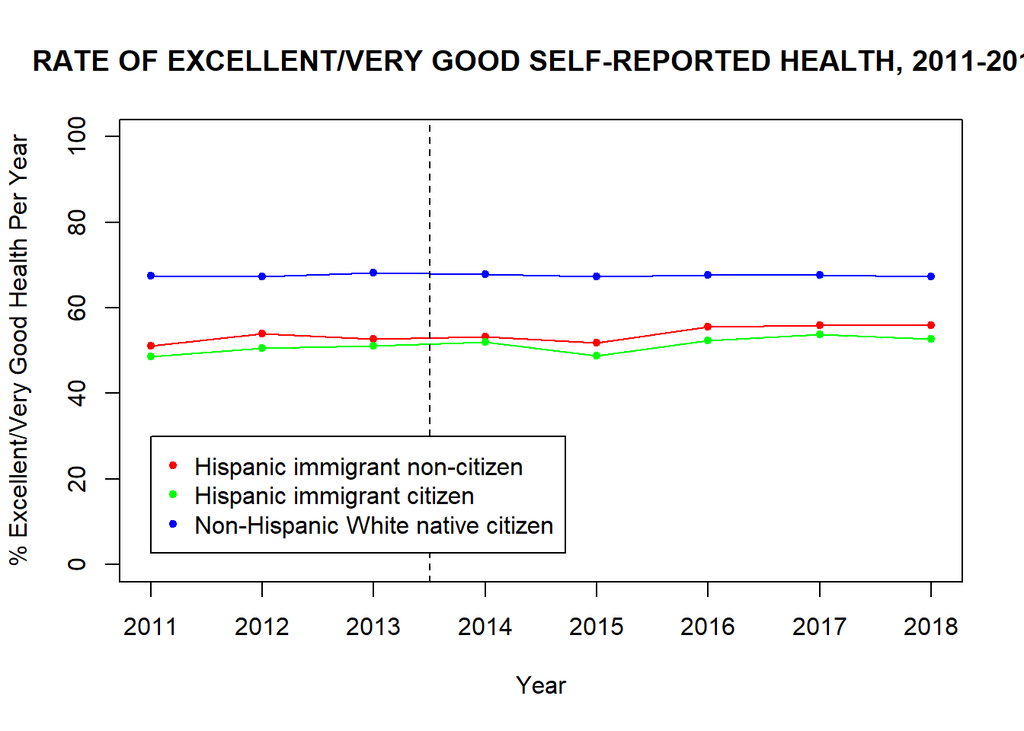

Overall, a higher proportion of non-Hispanic white native citizens reported excellent or very good health compared to the other groups. There is no obvious change in self-reported health status over the years.

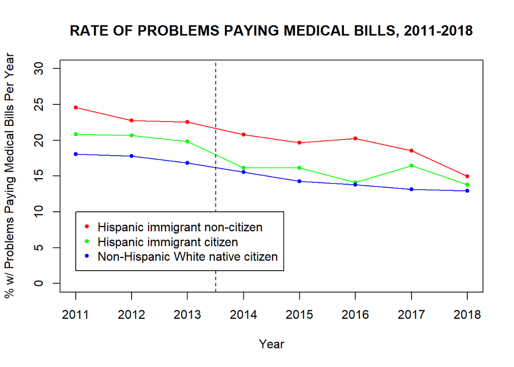

From 2011-2018, There has been an overall decrease rate of people having problems paying their medical bills, most noticeably amongst Hispanic immigrant non-citizens.

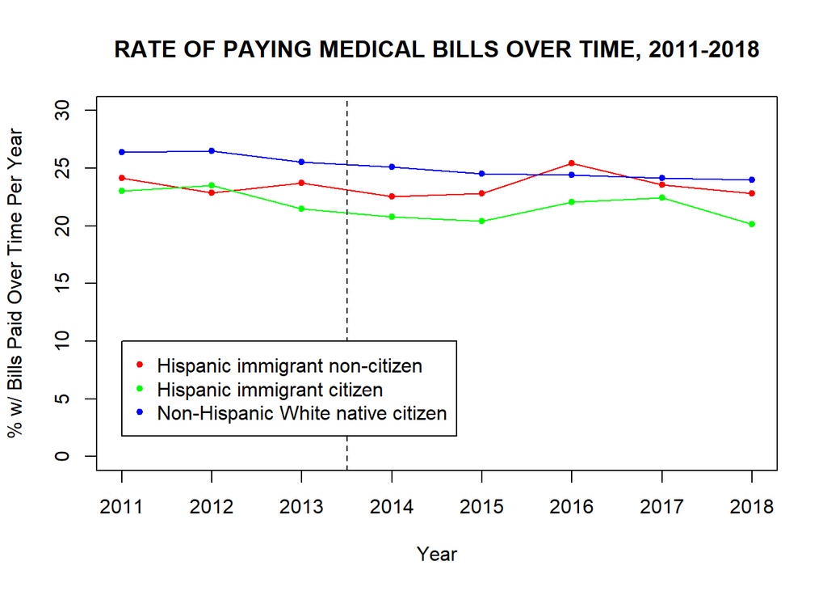

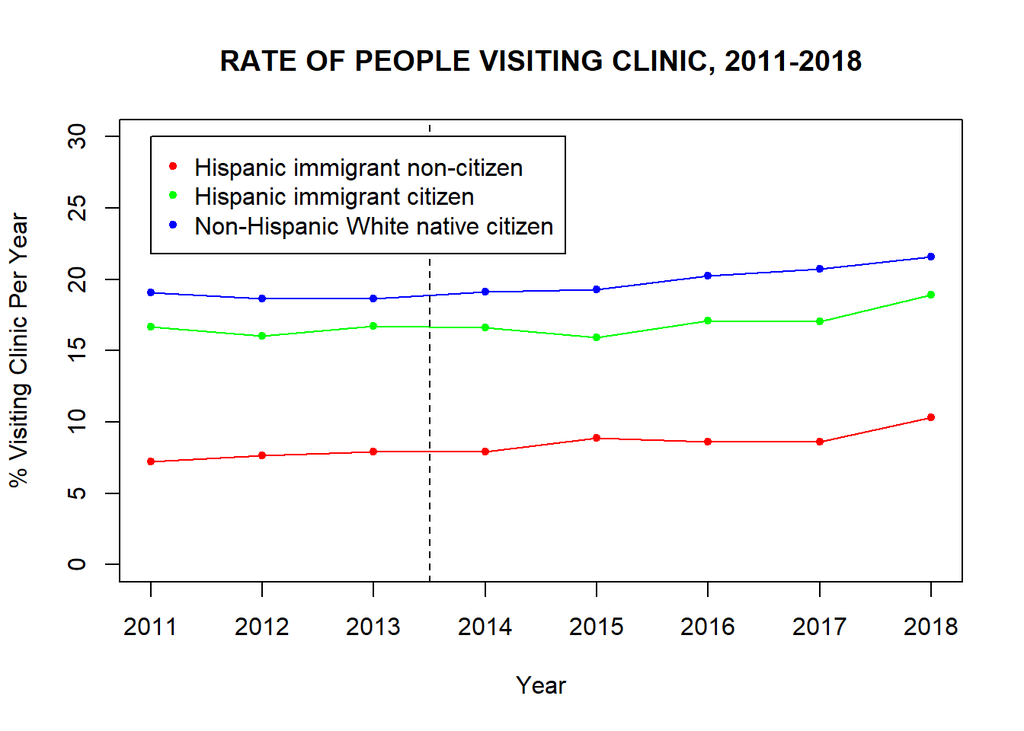

Overall, there appears to be a slight rise in people visiting health professionals in clinics. The most notable finding, however, is the large disparities in care-seeking with significantly lower rates amongst Hispanic immigrant non-citizens.

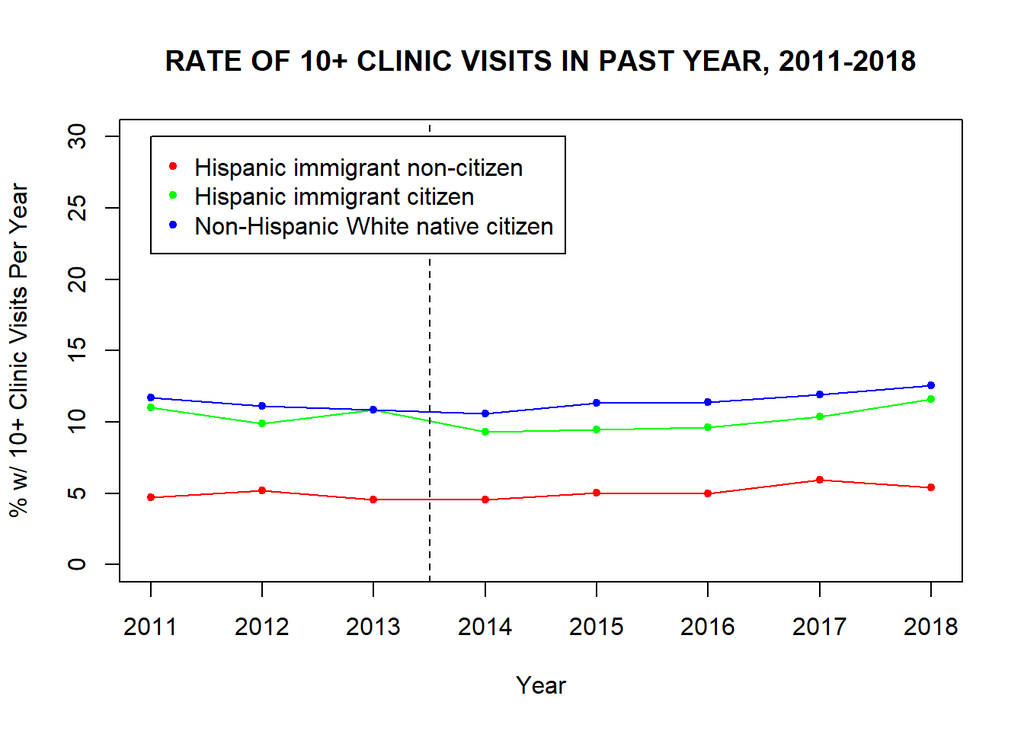

Similar to the previous visualization, there are significant differences in health care utilization between the citizens and non-citizens. There is no obvious change before and after 2014.

For the Table 1, statistical methods used were t-tests for continuous variables and chi-square tests for categorical variables.

For the time trend analysis, I considered various approaches including a logistic regression model with insurance status as the binary outcome and adding year as a covariate as well as a single-series interrupted time series analysis in order to look at the trends for access and utilization for Hispanic immigrants over time. I also considered a differences-in-differences analysis.

Ultimately, after reviewing prior literature and the available data, I decided to run a comparative interrupted time series analysis for my final model.

## Final Analysis

Given the trends observed in the exploratory analysis, I decided to run a comparative interrupted time series analysis to compare uninsured rates before and after Medicaid expansion in 2014 between Hispanic immigrants and white native citizens. I focused on these two populations because of the drastic disparities in insurance rates.

##### Comparative Interrupted Time Series Analysis

```r
nhisOutcomes$hisp <- ifelse(nhisOutcomes$immig==1,1,
                      ifelse(nhisOutcomes$immig==3,0,NA))

# Define level and slope before and after Medicaid expansion (2011-2013 vs 2014-2018)
nhisOutcomes$level <- ifelse(nhisOutcomes$time<4,0,1)
nhisOutcomes$slope <- ifelse(nhisOutcomes$time<4,0,nhisOutcomes$time-3)
nhisOutcomes$hisptime <- nhisOutcomes$hisp * nhisOutcomes$time
nhisOutcomes$hisplevel <- nhisOutcomes$hisp * nhisOutcomes$level
nhisOutcomes$hispslope <- nhisOutcomes$hisp * nhisOutcomes$slope

# Modeling OLS regression
olsreg<-lm(uninsuredrate ~ time + hisp + hisptime + level + slope + hisplevel +
               hispslope, data=nhisOutcomes)
summary(olsreg)
```

```
##
## Call:
## lm(formula = uninsuredrate ~ time + hisp + hisptime + level +
##     slope + hisplevel + hispslope, data = nhisOutcomes)
##
## Residuals:
##      Min       1Q   Median       3Q      Max
## -1.32854 -0.26266 -0.05323  0.38719  1.16390
##
## Coefficients:
##             Estimate Std. Error t value Pr(>|t|)
## (Intercept)  11.0260     1.2699   8.683 2.41e-05 ***
## time         -0.3002     0.5878  -0.511   0.6234
## hisp         50.4603     1.7959  28.098 2.78e-09 ***
## hisptime      0.3591     0.8313   0.432   0.6772
## level        -2.5686     1.1559  -2.222   0.0570 .
## slope        -0.2241     0.6439  -0.348   0.7368
## hisplevel    -3.4594     1.6347  -2.116   0.0672 .
## hispslope    -2.3004     0.9107  -2.526   0.0355 *
## ---
## Signif. codes:  0 '***' 0.001 '**' 0.01 '*' 0.05 '.' 0.1 ' ' 1
##
## Residual standard error: 0.8313 on 8 degrees of freedom
##   (16 observations deleted due to missingness)
## Multiple R-squared:  0.9994, Adjusted R-squared:  0.9988
## F-statistic:  1809 on 7 and 8 DF,  p-value: 3.72e-12
```

```r
confint(olsreg)
```

```
##                 2.5 %      97.5 %
## (Intercept)  8.097670 13.95436416
## time        -1.655741  1.05538180
## hisp        46.319040 54.60165644
## hisptime    -1.557948  2.27615858
## level       -5.234165  0.09694436
## slope       -1.709011  1.26087472
## hisplevel   -7.229106  0.31022099
## hispslope   -4.400377 -0.20032340
```

Through this model, I found that Hispanic immigrants (without citizenship) had a 50.5% rate of being uninsured compared to non-Hispanic white native citizens. Following the presumed time of Medicaid expansion (2014), there was a 3.5% decrease in uninsurance rate for Hispanic immigrants (not statiscally significant) and a *statistically significant drop in trend of 2.3% uninsurance rate each year after 2014*. These findings suggest that Medicaid expansion nationally may have been associated with significant improvements in insurance coverage for Hispanic immigrant non-citizens, compared to white citizens. Future analyses will adjust for covariates and autocorrelation in order to adjust for potential confounders.

As a final visualization, I plotted the actual trends for the two groups and their counterfactuals in order to visualize the effect of the intervention on both groups from 2011 to 2018.

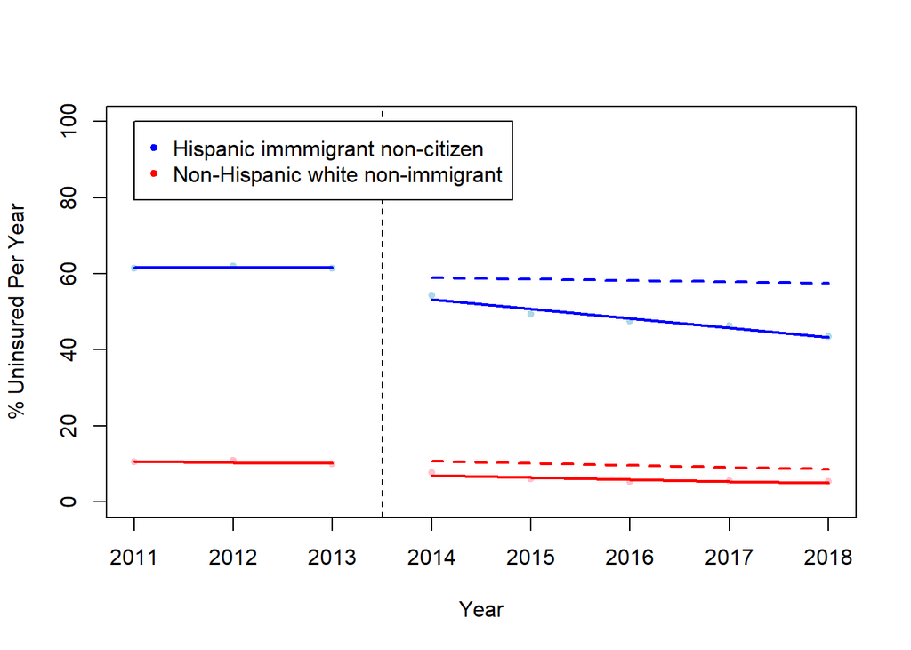

```r
### FINAL VISUALIZATION ###
nhisOutcomes <- nhisOutcomes %>% filter(!is.na(hisp))

# Plot data points, labels, and intervention time for Hispanic immigrants
plot(nhisOutcomes$time[1:8],nhisOutcomes$uninsuredrate[1:8],
     ylim=c(0,100),
     ylab="% Uninsured Per Year",
     xlab="Year",
     pch=20,
     col="lightblue",
     xaxt="n")

axis(1, at=1:8, labels=c(2011:2018))

abline(v=3.5,lty=2)

# Plot data points for white native citizens
points(nhisOutcomes$time[9:16],nhisOutcomes$uninsuredrate[9:16],
       col="pink",
       pch=20)

# Plot pre and post intervention lines for Hispanic immigrants
lines(nhisOutcomes$time[1:3], fitted(olsreg)[1:3], col="blue",lwd=2)
lines(nhisOutcomes$time[4:8], fitted(olsreg)[4:8], col="blue",lwd=2)

# Plot counterfactual for Hispanic immigrants
segments(4,
         olsreg$coef[1] + olsreg$coef[2]*4 +
           olsreg$coef[3] + olsreg$coef[4]*4 +
           olsreg$coef[5] + olsreg$coef[6], 8,
         olsreg$coef[1] + olsreg$coef[2]*8 +
           olsreg$coef[3] + olsreg$coef[4]*8 +
           olsreg$coef[5] + olsreg$coef[6]*8,
         lty=2,col='blue',lwd=2)

# Plot pre and post intervention lines for white native citizens
lines(nhisOutcomes$time[9:11], fitted(olsreg)[9:11], col="red",lwd=2)
lines(nhisOutcomes$time[12:16], fitted(olsreg)[12:16], col="red",lwd=2)

# Plot counterfactual for white native citizens
segments(4,
         olsreg$coef[1] + olsreg$coef[2],
         8,
         olsreg$coef[1] + olsreg$coef[2]*8,
         lty=2,col='red',lwd=2)

legend(x=1,y=100,
        legend=c("Hispanic immmigrant non-citizen","Non-Hispanic white non-immigrant"),
        col=c("blue","red"),
        pch=20)
```

## Final Thoughts

In summary, there large disparities in markers of health care access and utilization that disproportionately affect Hispanic immigrants, particularly those without U.S. citizenship. The ACA and its provisions may have been associated with increases in health insurance coverage, and there appears to be improvements in other markers of utilization such as delaying or missing care due to cost, though the cause needs to be explored further. Nevertheless, there are still persistent disparities among these populations and lack of improvement in self-reported health status. For this analysis, next steps will be to pursue deeper dives and adjusting for potential confounders. For U.S. health policy, if health equity is a priority then additional efforts are necessary to address the disparities that exist across lines by racial, ethnic, and immigration status.